# Big_mart_sales_prediction

*Import necessary libraries*

```python
import numpy as np
import pandas as pd
import matplotlib.pyplot as plt
import seaborn as sns
from sklearn.model_selection import train_test_split
from sklearn.linear_model import LinearRegression
from sklearn.tree import DecisionTreeRegressor
from sklearn.ensemble import RandomForestRegressor
from sklearn import metrics

import warnings
warnings.filterwarnings('ignore')
```

*Loading the train and test dataset*

```python
Train_data = pd.read_csv("bigmart_train.csv")
Test_data = pd.read_csv("bigmart_test.csv")
```

```python
Train_data.head()
```

|  | Item_Identifier | Item_Weight | Item_Fat_Content | Item_Visibility | Item_Type | Item_MRP | Outlet_Identifier | Outlet_Establishment_Year | Outlet_Size | Outlet_Location_Type | Outlet_Type | Item_Outlet_Sales |
| --- | --- | --- | --- | --- | --- | --- | --- | --- | --- | --- | --- | --- |
| 0 | FDA15 | 9.30 | Low Fat | 0.016047 | Dairy | 249.8092 | OUT049 | 1999 | Medium | Tier 1 | Supermarket Type1 | 3735.1380 |
| 1 | DRC01 | 5.92 | Regular | 0.019278 | Soft Drinks | 48.2692 | OUT018 | 2009 | Medium | Tier 3 | Supermarket Type2 | 443.4228 |
| 2 | FDN15 | 17.50 | Low Fat | 0.016760 | Meat | 141.6180 | OUT049 | 1999 | Medium | Tier 1 | Supermarket Type1 | 2097.2700 |
| 3 | FDX07 | 19.20 | Regular | 0.000000 | Fruits and Vegetables | 182.0950 | OUT010 | 1998 | NaN | Tier 3 | Grocery Store | 732.3800 |
| 4 | NCD19 | 8.93 | Low Fat | 0.000000 | Household | 53.8614 | OUT013 | 1987 | High | Tier 3 | Supermarket Type1 | 994.7052 |

```python
Test_data.head()
```

|  | Item_Identifier | Item_Weight | Item_Fat_Content | Item_Visibility | Item_Type | Item_MRP | Outlet_Identifier | Outlet_Establishment_Year | Outlet_Size | Outlet_Location_Type | Outlet_Type |
| --- | --- | --- | --- | --- | --- | --- | --- | --- | --- | --- | --- |
| 0 | FDW58 | 20.750 | Low Fat | 0.007565 | Snack Foods | 107.8622 | OUT049 | 1999 | Medium | Tier 1 | Supermarket Type1 |
| 1 | FDW14 | 8.300 | reg | 0.038428 | Dairy | 87.3198 | OUT017 | 2007 | NaN | Tier 2 | Supermarket Type1 |
| 2 | NCN55 | 14.600 | Low Fat | 0.099575 | Others | 241.7538 | OUT010 | 1998 | NaN | Tier 3 | Grocery Store |
| 3 | FDQ58 | 7.315 | Low Fat | 0.015388 | Snack Foods | 155.0340 | OUT017 | 2007 | NaN | Tier 2 | Supermarket Type1 |
| 4 | FDY38 | NaN | Regular | 0.118599 | Dairy | 234.2300 | OUT027 | 1985 | Medium | Tier 3 | Supermarket Type3 |

*Checking the shape of the datasets*

```python
print('Train data:', Train_data.shape)
print('Test data:', Test_data.shape)
```

```
Train data: (8523, 12)
Test data: (5681, 11)
```

*Description of the data*

```python
Train_data.describe().T
```

|  | count | mean | std | min | 25% | 50% | 75% | max |
| --- | --- | --- | --- | --- | --- | --- | --- | --- |
| Item_Weight | 7060.0 | 12.857645 | 4.643456 | 4.555 | 8.773750 | 12.600000 | 16.850000 | 21.350000 |
| Item_Visibility | 8523.0 | 0.066132 | 0.051598 | 0.000 | 0.026989 | 0.053931 | 0.094585 | 0.328391 |
| Item_MRP | 8523.0 | 140.992782 | 62.275067 | 31.290 | 93.826500 | 143.012800 | 185.643700 | 266.888400 |
| Outlet_Establishment_Year | 8523.0 | 1997.831867 | 8.371760 | 1985.000 | 1987.000000 | 1999.000000 | 2004.000000 | 2009.000000 |
| Item_Outlet_Sales | 8523.0 | 2181.288914 | 1706.499616 | 33.290 | 834.247400 | 1794.331000 | 3101.296400 | 13086.964800 |

*Checking null values in train and test data*

```python
Train_data.isnull().sum()
```

```
Item_Identifier                 0
Item_Weight                  1463
Item_Fat_Content                0
Item_Visibility                 0
Item_Type                       0
Item_MRP                        0
Outlet_Identifier               0
Outlet_Establishment_Year       0
Outlet_Size                  2410
Outlet_Location_Type            0
Outlet_Type                     0
Item_Outlet_Sales               0
dtype: int64
```

```python
Test_data.isnull().sum()
```

```
Item_Identifier                 0
Item_Weight                   976
Item_Fat_Content                0
Item_Visibility                 0
Item_Type                       0
Item_MRP                        0
Outlet_Identifier               0
Outlet_Establishment_Year       0
Outlet_Size                  1606
Outlet_Location_Type            0
Outlet_Type                     0
dtype: int64
```

*Concatenate the train and test data*

```python
# create a new column if it is train data the column tag is "train", if it is test data the tag is "test"
Train_data['source'] = 'train'
Test_data['source'] = 'test'
df = pd.concat([Train_data, Test_data], ignore_index=True)
```

```python
df.head()
```

|  | Item_Identifier | Item_Weight | Item_Fat_Content | Item_Visibility | Item_Type | Item_MRP | Outlet_Identifier | Outlet_Establishment_Year | Outlet_Size | Outlet_Location_Type | Outlet_Type | Item_Outlet_Sales | source |
| --- | --- | --- | --- | --- | --- | --- | --- | --- | --- | --- | --- | --- | --- |
| 0 | FDA15 | 9.30 | Low Fat | 0.016047 | Dairy | 249.8092 | OUT049 | 1999 | Medium | Tier 1 | Supermarket Type1 | 3735.1380 | train |
| 1 | DRC01 | 5.92 | Regular | 0.019278 | Soft Drinks | 48.2692 | OUT018 | 2009 | Medium | Tier 3 | Supermarket Type2 | 443.4228 | train |
| 2 | FDN15 | 17.50 | Low Fat | 0.016760 | Meat | 141.6180 | OUT049 | 1999 | Medium | Tier 1 | Supermarket Type1 | 2097.2700 | train |
| 3 | FDX07 | 19.20 | Regular | 0.000000 | Fruits and Vegetables | 182.0950 | OUT010 | 1998 | NaN | Tier 3 | Grocery Store | 732.3800 | train |
| 4 | NCD19 | 8.93 | Low Fat | 0.000000 | Household | 53.8614 | OUT013 | 1987 | High | Tier 3 | Supermarket Type1 | 994.7052 | train |

```python
df.tail()
```

|  | Item_Identifier | Item_Weight | Item_Fat_Content | Item_Visibility | Item_Type | Item_MRP | Outlet_Identifier | Outlet_Establishment_Year | Outlet_Size | Outlet_Location_Type | Outlet_Type | Item_Outlet_Sales | source |
| --- | --- | --- | --- | --- | --- | --- | --- | --- | --- | --- | --- | --- | --- |
| 14199 | FDB58 | 10.5 | Regular | 0.013496 | Snack Foods | 141.3154 | OUT046 | 1997 | Small | Tier 1 | Supermarket Type1 | NaN | test |
| 14200 | FDD47 | 7.6 | Regular | 0.142991 | Starchy Foods | 169.1448 | OUT018 | 2009 | Medium | Tier 3 | Supermarket Type2 | NaN | test |
| 14201 | NCO17 | 10.0 | Low Fat | 0.073529 | Health and Hygiene | 118.7440 | OUT045 | 2002 | NaN | Tier 2 | Supermarket Type1 | NaN | test |
| 14202 | FDJ26 | 15.3 | Regular | 0.000000 | Canned | 214.6218 | OUT017 | 2007 | NaN | Tier 2 | Supermarket Type1 | NaN | test |
| 14203 | FDU37 | 9.5 | Regular | 0.104720 | Canned | 79.7960 | OUT045 | 2002 | NaN | Tier 2 | Supermarket Type1 | NaN | test |

```python
# Check null values again
df.isnull().sum()
```

```
Item_Identifier                 0
Item_Weight                  2439
Item_Fat_Content                0
Item_Visibility                 0
Item_Type                       0
Item_MRP                        0
Outlet_Identifier               0
Outlet_Establishment_Year       0
Outlet_Size                  4016
Outlet_Location_Type            0
Outlet_Type                     0
Item_Outlet_Sales            5681
source                          0
dtype: int64
```

```python
df.shape
```

```
(14204, 13)
```

## **Visualization**

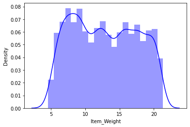

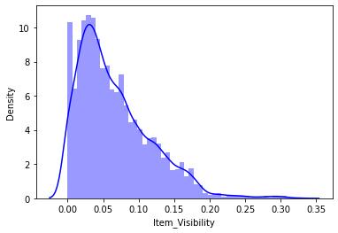

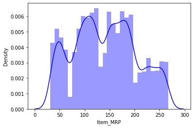

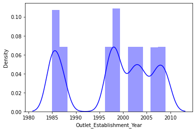

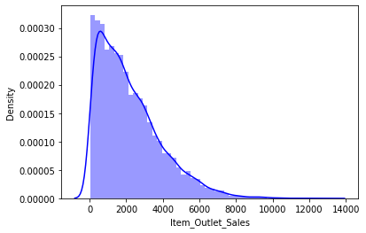

```python
for i in Train_data.describe().columns:
    sns.distplot(Train_data[i].dropna(), color='blue')
    plt.show()
```

- most of the item weight between 5 and 20.
- most of the item visibility is very low.
- in 1990 there is no establishment.
- most of the item outlet sales are between 0 and 4000.

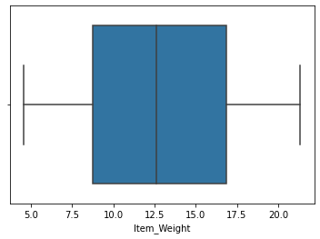

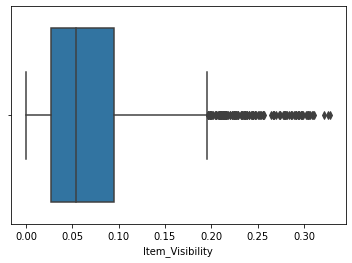

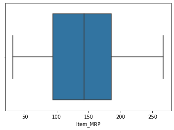

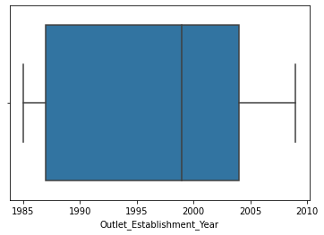

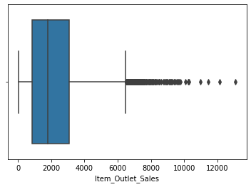

```python
for i in Train_data.describe().columns:
    sns.boxplot(Train_data[i].dropna())
    plt.show()
```

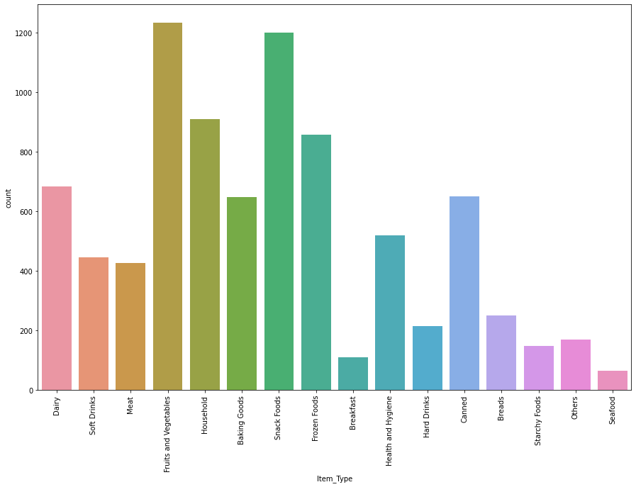

```python
# visualize the item type and distribution of each
plt.figure(figsize=(15,10))
sns.countplot(Train_data['Item_Type'])
plt.xticks(rotation=90)
plt.show()
```

```python
# most sold item type
Train_data['Item_Type'].value_counts()
```

```
Fruits and Vegetables    1232
Snack Foods              1200
Household                 910
Frozen Foods              856
Dairy                     682
Canned                    649
Baking Goods              648
Health and Hygiene        520
Soft Drinks               445
Meat                      425
Breads                    251
Hard Drinks               214
Others                    169
Starchy Foods             148
Breakfast                 110
Seafood                    64
Name: Item_Type, dtype: int64
```

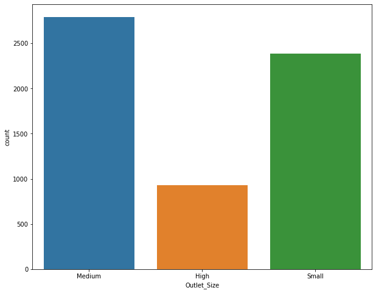

```python
# Distribution of the outlet_Size
plt.figure(figsize=(10,8))
sns.countplot(Train_data['Outlet_Size'])
plt.show()
```

- most of the outlets across the country are Medium size.
- very few outlet is High.

```python
Train_data['Outlet_Size'].value_counts()
```

```
Medium    2793
Small     2388
High       932
Name: Outlet_Size, dtype: int64
```

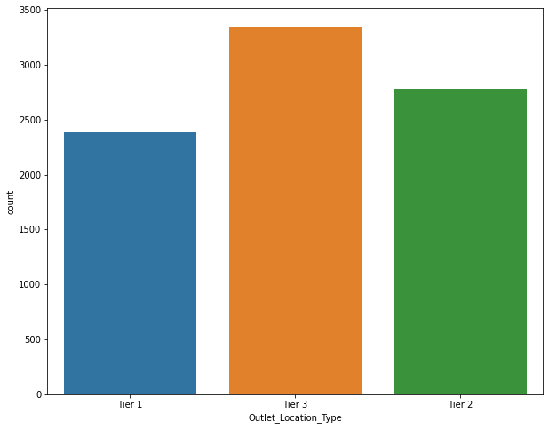

```python
# Distribution of Outlet_Location_Type
plt.figure(figsize=(10,8))
sns.countplot(Train_data['Outlet_Location_Type'])
plt.show()
```

- Most of the products located in Tier 3.

```python
Train_data['Outlet_Location_Type'].value_counts()
```

```
Tier 3    3350
Tier 2    2785
Tier 1    2388
Name: Outlet_Location_Type, dtype: int64
```

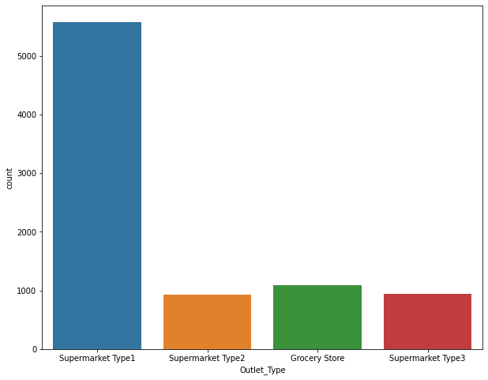

```python
# Distribution of outlet types
plt.figure(figsize=(10,8))
sns.countplot(Train_data['Outlet_Type'])
plt.show()
```

```python
Train_data['Outlet_Type'].value_counts()
```

```
Supermarket Type1    5577
Grocery Store        1083
Supermarket Type3     935
Supermarket Type2     928
Name: Outlet_Type, dtype: int64
```

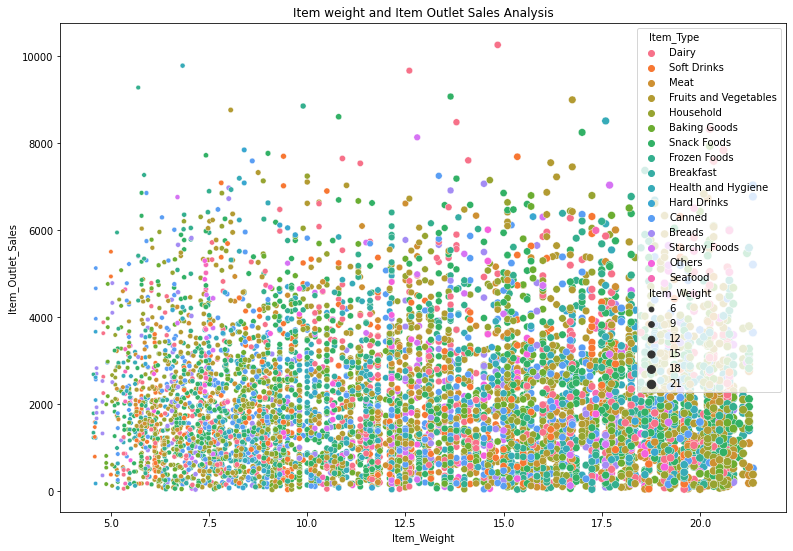

```python
# Relationship among item_weight and item_outlet_analysis
plt.figure(figsize=(13,9))
plt.xlabel('Item_Weight')
plt.ylabel('Item_Outlet_Sales')
plt.title('Item weight and Item Outlet Sales Analysis')
sns.scatterplot(x='Item_Weight', y='Item_Outlet_Sales', hue='Item_Type', size='Item_Weight', data=Train_data)
plt.show()
```

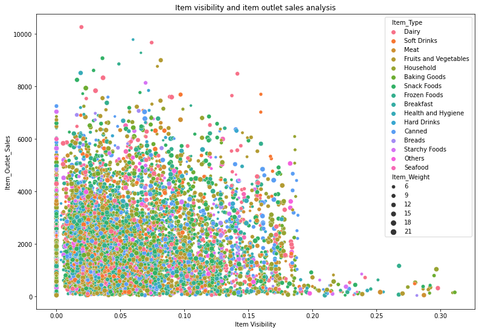

```python
# Relationship between Item_Visibility and Item_Outlet_Sales
plt.figure(figsize=(13,9))
plt.xlabel('Item Visibility')
plt.ylabel('Item_Outlet_Sales')
plt.title('Item visibility and item outlet sales analysis')
sns.scatterplot(x='Item_Visibility', y='Item_Outlet_Sales', hue='Item_Type', size='Item_Weight', data=Train_data)
plt.show()
```

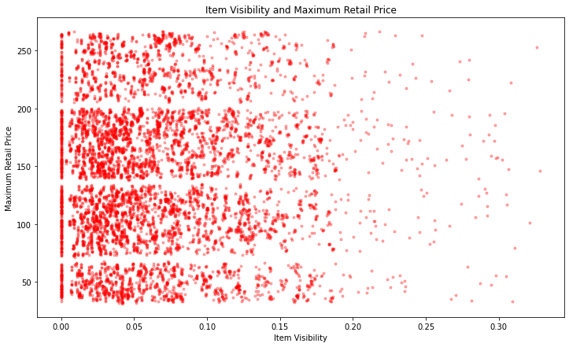

```python
plt.figure(figsize=(12,7))
plt.xlabel('Item Visibility')
plt.ylabel('Maximum Retail Price')
plt.title('Item Visibility and Maximum Retail Price')
plt.plot(Train_data.Item_Visibility, Train_data.Item_MRP, ".", alpha=0.3, color='red')
plt.show()
```

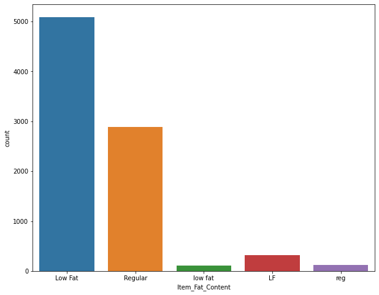

```python
# Distribution of Item_Fat_Content
plt.figure(figsize=(10,8))
sns.countplot(Train_data['Item_Fat_Content'])
plt.show()
```

```python
Train_data['Item_Fat_Content'].value_counts()
```

```
Low Fat    5089
Regular    2889
LF          316
reg         117
low fat     112
Name: Item_Fat_Content, dtype: int64
```

```python
# Rename the fat content column to readable
df['Item_Fat_Content'] = df['Item_Fat_Content'].replace({'LF' : 'Low Fat', 'reg' : 'Regular', 'low fat' : 'Low Fat'})
```

```python
df['Item_Fat_Content'].value_counts()
```

```
Low Fat    9185
Regular    5019
Name: Item_Fat_Content, dtype: int64
```

```python
# Doing this into train data
Train_data['Item_Fat_Content'] = Train_data['Item_Fat_Content'].replace({'LF' : 'Low Fat', 'reg' : 'Regular', 'low fat' : 'Low Fat'})
```

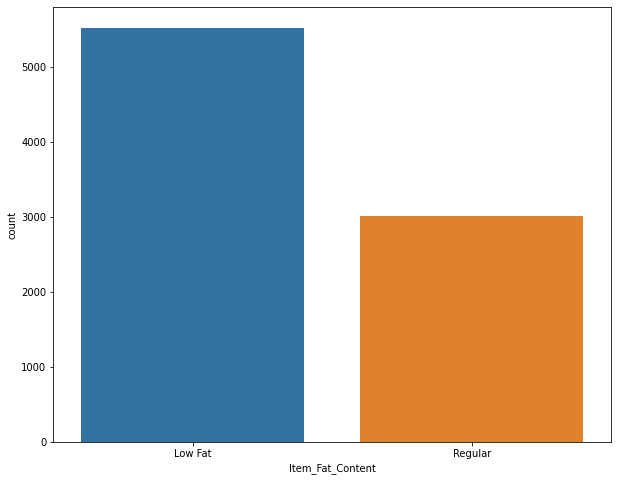

```python
# Distribution of Item_Fat_Content
plt.figure(figsize=(10, 8))
sns.countplot(Train_data['Item_Fat_Content'])
plt.show()
```

```python
Train_data['Item_Fat_Content'].value_counts()
```

```
Low Fat    5517
Regular    3006
Name: Item_Fat_Content, dtype: int64
```

```python
# Check the correlation
Train_data.corr()
```

|  | Item_Weight | Item_Visibility | Item_MRP | Outlet_Establishment_Year | Item_Outlet_Sales |
| --- | --- | --- | --- | --- | --- |
| Item_Weight | 1.000000 | -0.014048 | 0.027141 | -0.011588 | 0.014123 |
| Item_Visibility | -0.014048 | 1.000000 | -0.001315 | -0.074834 | -0.128625 |
| Item_MRP | 0.027141 | -0.001315 | 1.000000 | 0.005020 | 0.567574 |
| Outlet_Establishment_Year | -0.011588 | -0.074834 | 0.005020 | 1.000000 | -0.049135 |
| Item_Outlet_Sales | 0.014123 | -0.128625 | 0.567574 | -0.049135 | 1.000000 |

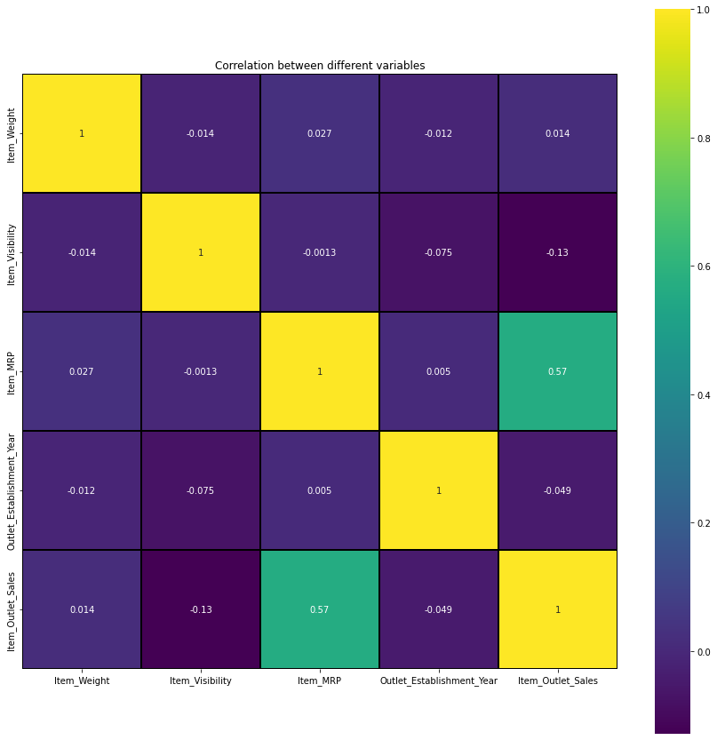

```python
# Correlation heatmap
plt.figure(figsize=(15,15))
sns.heatmap(Train_data.corr(), annot=True, square=True, cmap='viridis', linecolor='k', linewidths=0.1)
plt.title('Correlation between different variables')
plt.show()
```

```python
Train_data.columns
```

```
Index(['Item_Identifier', 'Item_Weight', 'Item_Fat_Content', 'Item_Visibility',
       'Item_Type', 'Item_MRP', 'Outlet_Identifier',
       'Outlet_Establishment_Year', 'Outlet_Size', 'Outlet_Location_Type',
       'Outlet_Type', 'Item_Outlet_Sales', 'source'],
      dtype='object')
```

*Dealing with null values*

Item_Weight and Outlet_size columns having null values.

```python
df['Item_Weight'].mean()
```

```
12.792854228644991
```

```python
df['Item_Weight'].fillna(df['Item_Weight'].mean(), inplace=True)
```

- Outlet_size column is a object and replace with Medium size which is most shown value in that column.

```python
df['Outlet_Size'].value_counts()
```

```
Medium    4655
Small     3980
High      1553
Name: Outlet_Size, dtype: int64
```

```python
df['Outlet_Size'].fillna('Medium', inplace=True)
```

```python
df.isnull().sum()
```

```
Item_Identifier                 0
Item_Weight                     0
Item_Fat_Content                0
Item_Visibility                 0
Item_Type                       0
Item_MRP                        0
Outlet_Identifier               0
Outlet_Establishment_Year       0
Outlet_Size                     0
Outlet_Location_Type            0
Outlet_Type                     0
Item_Outlet_Sales            5681
source                          0
dtype: int64
```

**Item Visibility**

```python
Train_data.describe().T
```

|  | count | mean | std | min | 25% | 50% | 75% | max |
| --- | --- | --- | --- | --- | --- | --- | --- | --- |
| Item_Weight | 7060.0 | 12.857645 | 4.643456 | 4.555 | 8.773750 | 12.600000 | 16.850000 | 21.350000 |
| Item_Visibility | 8523.0 | 0.066132 | 0.051598 | 0.000 | 0.026989 | 0.053931 | 0.094585 | 0.328391 |
| Item_MRP | 8523.0 | 140.992782 | 62.275067 | 31.290 | 93.826500 | 143.012800 | 185.643700 | 266.888400 |
| Outlet_Establishment_Year | 8523.0 | 1997.831867 | 8.371760 | 1985.000 | 1987.000000 | 1999.000000 | 2004.000000 | 2009.000000 |
| Item_Outlet_Sales | 8523.0 | 2181.288914 | 1706.499616 | 33.290 | 834.247400 | 1794.331000 | 3101.296400 | 13086.964800 |

- The Item_Visibility column minimum value is 0 and we need to treat that value as missing value. The Item 0 means it not available. Instead of NaN it marked as 0.

```python
# count the total number of 0 in the Item Visibility column.
df[df['Item_Visibility'] == 0]['Item_Visibility'].count()
```

```
879
```

```python
df['Item_Visibility'].fillna(df['Item_Visibility'].median(), inplace=True)
```

**Outlet Years**

```python
df['Outlet_Establishment_Year'].value_counts()
```

```
1985    2439
1987    1553
1999    1550
1997    1550
2004    1550
2002    1548
2009    1546
2007    1543
1998     925
Name: Outlet_Establishment_Year, dtype: int64
```

to know how the period to making new outlet established from the starting(1985) and 2009.

```python
df['Outlet_Years'] = 2009 - df['Outlet_Establishment_Year']
df['Outlet_Years'].describe().T
```

```
count    14204.000000
mean        11.169319
std          8.371664
min          0.000000
25%          5.000000
50%         10.000000
75%         22.000000
max         24.000000
Name: Outlet_Years, dtype: float64
```

```python
df['Item_Type'].value_counts()
```

```
Fruits and Vegetables    2013
Snack Foods              1989
Household                1548
Frozen Foods             1426
Dairy                    1136
Baking Goods             1086
Canned                   1084
Health and Hygiene        858
Meat                      736
Soft Drinks               726
Breads                    416
Hard Drinks               362
Others                    280
Starchy Foods             269
Breakfast                 186
Seafood                    89
Name: Item_Type, dtype: int64
```

```python
Train_data.columns
```

```
Index(['Item_Identifier', 'Item_Weight', 'Item_Fat_Content', 'Item_Visibility',
       'Item_Type', 'Item_MRP', 'Outlet_Identifier',
       'Outlet_Establishment_Year', 'Outlet_Size', 'Outlet_Location_Type',
       'Outlet_Type', 'Item_Outlet_Sales', 'source'],
      dtype='object')
```

The Item_Type associated with an Item_Identifier

```python
df['Item_Identifier'].value_counts()
```

```
FDU15    10
FDS25    10
FDA38    10
FDW03    10
FDJ10    10
         ..
FDR51     7
FDM52     7
DRN11     7
FDH58     7
NCW54     7
Name: Item_Identifier, Length: 1559, dtype: int64
```

group them into three category FD(Food), DR(Drink) and NC(Non consumable).

```python
# pick only first two character eg: 'FDU15' take only index 0,1 which means (FD)
df["New_Item_Type"] = df["Item_Identifier"].apply(lambda x: x[0:2])
```

```python
# Rename the values FD=Food, DR=Drink and NC= Non Consumable
df["New_Item_Type"] = df["New_Item_Type"].map({'FD':'Food', 'NC':'Non-Consumable', 'DR':'Drinks'})
```

```python
df['New_Item_Type'].value_counts()
```

```
Food              10201
Non-Consumable     2686
Drinks             1317
Name: New_Item_Type, dtype: int64
```

If a product is non consumable then why associate a fat content to them.Locate the non consumable in "New Item Type" column and Non consumable associate with Fat content and rename it as Non-edible.

```python
df.loc[df['New_Item_Type'] == "Non-Consumable","Item_Fat_Content"] = "Non-Edible"
```

```python
df['Item_Fat_Content'].value_counts()
```

```
Low Fat       6499
Regular       5019
Non-Edible    2686
Name: Item_Fat_Content, dtype: int64
```

```python
item_visib_avg = df.pivot_table(values='Item_Visibility', index="Item_Identifier")
```

```python
item_visib_avg
```

| Item_Identifier | Item_Visibility |
| --- | --- |
| DRA12 | 0.034938 |
| DRA24 | 0.045646 |
| DRA59 | 0.133384 |
| DRB01 | 0.079736 |
| DRB13 | 0.006799 |
| ... | ... |
| NCZ30 | 0.027302 |
| NCZ41 | 0.056396 |
| NCZ42 | 0.011015 |
| NCZ53 | 0.026330 |
| NCZ54 | 0.081345 |

1559 rows × 1 columns

```python
function = lambda x: x['Item_Visibility'] / item_visib_avg['Item_Visibility'][item_visib_avg.index == x["Item_Identifier"]][0]
df["item_visib_avg"] = df.apply(function, axis=1).astype(float)
```

```python
df.head()
```

|  | Item_Identifier | Item_Weight | Item_Fat_Content | Item_Visibility | Item_Type | Item_MRP | Outlet_Identifier | Outlet_Establishment_Year | Outlet_Size | Outlet_Location_Type | Outlet_Type | Item_Outlet_Sales | source | Outlet_Years | New_Item_Type | item_visib_avg |
| --- | --- | --- | --- | --- | --- | --- | --- | --- | --- | --- | --- | --- | --- | --- | --- | --- |
| 0 | FDA15 | 9.30 | Low Fat | 0.016047 | Dairy | 249.8092 | OUT049 | 1999 | Medium | Tier 1 | Supermarket Type1 | 3735.1380 | train | 10 | Food | 0.931078 |
| 1 | DRC01 | 5.92 | Regular | 0.019278 | Soft Drinks | 48.2692 | OUT018 | 2009 | Medium | Tier 3 | Supermarket Type2 | 443.4228 | train | 0 | Drinks | 0.933420 |
| 2 | FDN15 | 17.50 | Low Fat | 0.016760 | Meat | 141.6180 | OUT049 | 1999 | Medium | Tier 1 | Supermarket Type1 | 2097.2700 | train | 10 | Food | 0.960069 |
| 3 | FDX07 | 19.20 | Regular | 0.000000 | Fruits and Vegetables | 182.0950 | OUT010 | 1998 | Medium | Tier 3 | Grocery Store | 732.3800 | train | 11 | Food | 0.000000 |
| 4 | NCD19 | 8.93 | Non-Edible | 0.000000 | Household | 53.8614 | OUT013 | 1987 | High | Tier 3 | Supermarket Type1 | 994.7052 | train | 22 | Non-Consumable | 0.000000 |

**Dealing with Categorical Varibales**

```python
from sklearn.preprocessing import LabelEncoder
le = LabelEncoder()

df['Outlet'] = le.fit_transform(df['Outlet_Identifier'])
variable = ['Item_Fat_Content', 'Outlet_Location_Type', 'Outlet_Size', 'New_Item_Type', 'Outlet_Type', 'Outlet']
for i in variable:
    df[i] = le.fit_transform(df[i])
```

```python
df.head()
```

|  | Item_Identifier | Item_Weight | Item_Fat_Content | Item_Visibility | Item_Type | Item_MRP | Outlet_Identifier | Outlet_Establishment_Year | Outlet_Size | Outlet_Location_Type | Outlet_Type | Item_Outlet_Sales | source | Outlet_Years | New_Item_Type | item_visib_avg | Outlet |
| --- | --- | --- | --- | --- | --- | --- | --- | --- | --- | --- | --- | --- | --- | --- | --- | --- | --- |
| 0 | FDA15 | 9.30 | 0 | 0.016047 | Dairy | 249.8092 | OUT049 | 1999 | 1 | 0 | 1 | 3735.1380 | train | 10 | 1 | 0.931078 | 9 |
| 1 | DRC01 | 5.92 | 2 | 0.019278 | Soft Drinks | 48.2692 | OUT018 | 2009 | 1 | 2 | 2 | 443.4228 | train | 0 | 0 | 0.933420 | 3 |
| 2 | FDN15 | 17.50 | 0 | 0.016760 | Meat | 141.6180 | OUT049 | 1999 | 1 | 0 | 1 | 2097.2700 | train | 10 | 1 | 0.960069 | 9 |
| 3 | FDX07 | 19.20 | 2 | 0.000000 | Fruits and Vegetables | 182.0950 | OUT010 | 1998 | 1 | 2 | 0 | 732.3800 | train | 11 | 1 | 0.000000 | 0 |
| 4 | NCD19 | 8.93 | 1 | 0.000000 | Household | 53.8614 | OUT013 | 1987 | 0 | 2 | 1 | 994.7052 | train | 22 | 2 | 0.000000 | 1 |

create dummy variables for these Label Encoded variables to avoid our algorithm ranking these labels

```python
# Dummy variable
df = pd.get_dummies(df, columns=['Item_Fat_Content', 'Outlet_Location_Type', 'Outlet_Size', 'New_Item_Type', 'Outlet_Type', 'Outlet'])
df.dtypes
```

```
Item_Identifier               object
Item_Weight                  float64
Item_Visibility              float64
Item_Type                     object
Item_MRP                     float64
Outlet_Identifier             object
Outlet_Establishment_Year      int64
Item_Outlet_Sales            float64
source                        object
Outlet_Years                   int64
item_visib_avg               float64
Item_Fat_Content_0             uint8
Item_Fat_Content_1             uint8
Item_Fat_Content_2             uint8
Outlet_Location_Type_0         uint8
Outlet_Location_Type_1         uint8
Outlet_Location_Type_2         uint8
Outlet_Size_0                  uint8
Outlet_Size_1                  uint8
Outlet_Size_2                  uint8
New_Item_Type_0                uint8
New_Item_Type_1                uint8
New_Item_Type_2                uint8
Outlet_Type_0                  uint8
Outlet_Type_1                  uint8
Outlet_Type_2                  uint8
Outlet_Type_3                  uint8
Outlet_0                       uint8
Outlet_1                       uint8
Outlet_2                       uint8
Outlet_3                       uint8
Outlet_4                       uint8
Outlet_5                       uint8
Outlet_6                       uint8
Outlet_7                       uint8
Outlet_8                       uint8
Outlet_9                       uint8
dtype: object
```

```python
df.head()
```

|  | Item_Identifier | Item_Weight | Item_Visibility | Item_Type | Item_MRP | Outlet_Identifier | Outlet_Establishment_Year | Item_Outlet_Sales | source | Outlet_Years | ... | Outlet_0 | Outlet_1 | Outlet_2 | Outlet_3 | Outlet_4 | Outlet_5 | Outlet_6 | Outlet_7 | Outlet_8 | Outlet_9 |
| --- | --- | --- | --- | --- | --- | --- | --- | --- | --- | --- | --- | --- | --- | --- | --- | --- | --- | --- | --- | --- | --- |
| 0 | FDA15 | 9.30 | 0.016047 | Dairy | 249.8092 | OUT049 | 1999 | 3735.1380 | train | 10 | ... | 0 | 0 | 0 | 0 | 0 | 0 | 0 | 0 | 0 | 1 |
| 1 | DRC01 | 5.92 | 0.019278 | Soft Drinks | 48.2692 | OUT018 | 2009 | 443.4228 | train | 0 | ... | 0 | 0 | 0 | 1 | 0 | 0 | 0 | 0 | 0 | 0 |
| 2 | FDN15 | 17.50 | 0.016760 | Meat | 141.6180 | OUT049 | 1999 | 2097.2700 | train | 10 | ... | 0 | 0 | 0 | 0 | 0 | 0 | 0 | 0 | 0 | 1 |
| 3 | FDX07 | 19.20 | 0.000000 | Fruits and Vegetables | 182.0950 | OUT010 | 1998 | 732.3800 | train | 11 | ... | 1 | 0 | 0 | 0 | 0 | 0 | 0 | 0 | 0 | 0 |
| 4 | NCD19 | 8.93 | 0.000000 | Household | 53.8614 | OUT013 | 1987 | 994.7052 | train | 22 | ... | 0 | 1 | 0 | 0 | 0 | 0 | 0 | 0 | 0 | 0 |

5 rows × 37 columns

### **Model Building**

We created the item type column to 3 category(food, non-consumable and drinks) we don't need that 16 category for that we need to drop that Item_Type column

```python
df.drop(['Item_Type', 'Outlet_Establishment_Year'], axis=1, inplace=True)
```

```python
# select and store the source train and test
train = df.loc[df['source'] == 'train']
test = df.loc[df['source'] == 'test']
```

```python
# drop the source column in train data
train.drop(['source'], axis=1, inplace=True)
```

```python
# drop sales and test column in test data
test.drop(['Item_Outlet_Sales', 'source'], axis=1, inplace=True)
```

```python
# drop the sales which our target column and stored into as y_train column and also drop Item_Identifier and Outlet_Identifier columns.
X_train = train.drop(['Item_Outlet_Sales', 'Item_Identifier', 'Outlet_Identifier'], axis=1)
y_train = train['Item_Outlet_Sales']
X_test = test.drop(['Item_Identifier', 'Outlet_Identifier'], axis=1).copy()
```

- ## **Linear Regression**

```python
lr = LinearRegression(normalize=True)
lr.fit(X_train, y_train)
```

```
LinearRegression(normalize=True)
```

```python
lr_pred = lr.predict(X_test)
```

```python
lr_pred
```

```
array([1859.5, 1575.5, 1872.5, ..., 1805. , 3575.5, 1262. ])
```

```python
lr_accuracy = round(lr.score(X_train, y_train)*100)
lr_accuracy
```

```
56
```

- ## **DecisionTree Regressor**

```python
dtree = DecisionTreeRegressor(max_depth=15, min_samples_leaf=100)
dtree.fit(X_train, y_train)
```

```
DecisionTreeRegressor(max_depth=15, min_samples_leaf=100)
```

```python
dtree_pred = dtree.predict(X_test)
dtree_pred
```

```
array([1649.67954808, 1412.15620504,  584.75776477, ..., 1827.83284545,
       3692.81910244, 1211.249992  ])
```

```python
dtree_accuracy = round(dtree.score(X_train, y_train)*100)
dtree_accuracy
```

```
62
```

## **Random Forest Regressor**

```python
from sklearn.model_selection import KFold, GridSearchCV
```

```python
rfr = RandomForestRegressor(n_estimators=400, max_depth=6, min_samples_leaf=100, n_jobs=2)
rfr.fit(X_train, y_train)
```

```
RandomForestRegressor(max_depth=6, min_samples_leaf=100, n_estimators=400,
                      n_jobs=2)
```

```python
rf_pred = rfr.predict(X_test)
rf_pred
```

```
array([1655.88301941, 1364.68865901,  572.42047205, ..., 1925.92541313,
       3676.08148544, 1304.403192  ])
```

```python
rf_accuracy = round(rfr.score(X_train, y_train)*100)
rf_accuracy
```

```
61
```

```python
# using hyper parameter tuning
param_grid = {'n_estimators': [200, 300, 400],
               'max_depth': [2, 5, 8], 'max_features': [2, 5, 8], 'min_samples_leaf': [10, 20, 30],
               'n_jobs': [2, 5, 8]}
```

```python
gs = GridSearchCV(RandomForestRegressor(), param_grid=param_grid, cv=5)
gs.fit(X_train, y_train)
```

```
GridSearchCV(cv=5, estimator=RandomForestRegressor(),
             param_grid={'max_depth': [2, 5, 8], 'max_features': [2, 5, 8],
                         'min_samples_leaf': [10, 20, 30],
                         'n_estimators': [200, 300, 400], 'n_jobs': [2, 5, 8]})
```

```python
gs.best_params_
```

```
{'max_depth': 8,
 'max_features': 8,
 'min_samples_leaf': 10,
 'n_estimators': 300,
 'n_jobs': 2}
```

```python
Rfr = RandomForestRegressor(n_estimators=300, max_depth=8, max_features=8, min_samples_leaf=10, n_jobs=2)
Rfr.fit(X_train, y_train)
```

```
RandomForestRegressor(max_depth=8, max_features=8, min_samples_leaf=10,
                      n_estimators=300, n_jobs=2)
```

```python
Rfr_pred = Rfr.predict(X_test)
Rfr_pred
```

```
array([1763.57348767, 1488.51236905,  561.72851595, ..., 1829.82336319,
       3600.29600514, 1437.20671134])
```

```python
Rfr_accuracy = round(Rfr.score(X_train, y_train)*100)
Rfr_accuracy
```

```
61
```

## **XGBoost Regressor**

```python
from xgboost import XGBRegressor

xgb = XGBRegressor(n_estimators=1000, learning_rate=0.05)
xgb.fit(X_train, y_train)
```

```
XGBRegressor(base_score=None, booster=None, callbacks=None,
             colsample_bylevel=None, colsample_bynode=None,
             colsample_bytree=None, early_stopping_rounds=None,
             enable_categorical=False, eval_metric=None, feature_types=None,
             gamma=None, gpu_id=None, grow_policy=None, importance_type=None,
             interaction_constraints=None, learning_rate=0.05, max_bin=None,
             max_cat_threshold=None, max_cat_to_onehot=None,
             max_delta_step=None, max_depth=None, max_leaves=None,
             min_child_weight=None, missing=nan, monotone_constraints=None,
             n_estimators=1000, n_jobs=None, num_parallel_tree=None,
             predictor=None, random_state=None, ...)
```

```python
xgb_pred = xgb.predict(X_test)
xgb_pred
```

```
array([1466.5479, 1350.2109,  630.7106, ..., 2057.4688, 4970.335 ,
       1451.6243], dtype=float32)
```

```python
xgb_accuracy = round(xgb.score(X_train, y_train)*100)
xgb_accuracy
```

```
88
```

## **Bagging Regressor**

```python
from sklearn.ensemble import BaggingRegressor

bgr = BaggingRegressor(base_estimator=dtree, n_estimators=50, random_state=42)
bgr.fit(X_train, y_train)
```

```
BaggingRegressor(base_estimator=DecisionTreeRegressor(max_depth=15,
                                                      min_samples_leaf=100),
                 n_estimators=50, random_state=42)
```

```python
bgr_pred = bgr.predict(X_test)
bgr_pred
```

```
array([1579.6902436 , 1355.13161168,  572.14094863, ..., 1866.45677585,
       3724.86406912, 1291.76477391])
```

```python
bgr_accuracy = round(bgr.score(X_train, y_train)*100)
bgr_accuracy
```

```
61
```

## **Support Vector Regressor**

```python
from sklearn import svm

svr = svm.SVR(C=5)
svr.fit(X_train, y_train)
```

```
SVR(C=5)
```

```python
svr_pred = svr.predict(X_test)
svr_pred
```

```
array([1569.34344646, 1255.50406586, 3180.96937362, ..., 1741.19381328,
       3037.44095917, 1156.93653262])
```

```python
svr_accuracy = round(svr.score(X_train, y_train)*100)
svr_accuracy
```

```
30
```

## **GradientBoost Regressor**

```python
from sklearn.ensemble import GradientBoostingRegressor

gbr = GradientBoostingRegressor(n_estimators=50, random_state=42)
gbr.fit(X_train, y_train)
```

```
GradientBoostingRegressor(n_estimators=50, random_state=42)
```

```python
gbr_pred = gbr.predict(X_test)
gbr_pred
```

```
array([1678.86634646, 1346.07711325,  557.39191603, ..., 1885.42423784,
       3595.32012622, 1306.86197903])
```

```python
gbr_accuracy = round(gbr.score(X_train, y_train)*100)
gbr_accuracy
```

```
62
```

```python
# showing all algorithm accuracies
print('LinearRegression Accuracy:', lr_accuracy)
print('DecisionTreeRegressor Accuracy:', dtree_accuracy)
print('RandomForestRegressor Accuracy:', rf_accuracy)
print('RandomForestRegressor hyper Accuracy:', Rfr_accuracy)
print('XGBRegressor Accuracy:', xgb_accuracy)
print('SVR Accuracy:', svr_accuracy)
print('GradientBoostingRegressor Accuracy:', gbr_accuracy)
```

```
LinearRegression Accuracy: 56
DecisionTreeRegressor Accuracy: 62
RandomForestRegressor Accuracy: 61
RandomForestRegressor hyper Accuracy: 61
XGBRegressor Accuracy: 88
SVR Accuracy: 30
GradientBoostingRegressor Accuracy: 62
```

here i'm showing all the training accuracies and the better score is showing XGBoost Regressor 88 and the worst accuracy is showing support vector regressor the score is 30.